# Optimal Treatment Analysis

## Outcome Variable

**Outcome Variable:** haz

## Predictor Variables

**Intervention Variable:** month

**Adjustment Set:**

unadjusted

## Stratifying Variables

The analysis was stratified on these variable(s):

- agecat
- studyid
- country

## Data Summary

| agecat | studyid | country | month | n_cell | n |
| --- | --- | --- | --- | --- | --- |
| Birth | ki0047075b-MAL-ED | BANGLADESH | 1 | 19 | 257 |
| Birth | ki0047075b-MAL-ED | BANGLADESH | 2 | 24 | 257 |
| Birth | ki0047075b-MAL-ED | BANGLADESH | 3 | 28 | 257 |
| Birth | ki0047075b-MAL-ED | BANGLADESH | 4 | 21 | 257 |
| Birth | ki0047075b-MAL-ED | BANGLADESH | 5 | 21 | 257 |
| Birth | ki0047075b-MAL-ED | BANGLADESH | 6 | 9 | 257 |
| Birth | ki0047075b-MAL-ED | BANGLADESH | 7 | 22 | 257 |
| Birth | ki0047075b-MAL-ED | BANGLADESH | 8 | 25 | 257 |
| Birth | ki0047075b-MAL-ED | BANGLADESH | 9 | 22 | 257 |
| Birth | ki0047075b-MAL-ED | BANGLADESH | 10 | 24 | 257 |
| Birth | ki0047075b-MAL-ED | BANGLADESH | 11 | 15 | 257 |
| Birth | ki0047075b-MAL-ED | BANGLADESH | 12 | 27 | 257 |
| Birth | ki0047075b-MAL-ED | BRAZIL | 1 | 9 | 191 |
| Birth | ki0047075b-MAL-ED | BRAZIL | 2 | 21 | 191 |
| Birth | ki0047075b-MAL-ED | BRAZIL | 3 | 18 | 191 |
| Birth | ki0047075b-MAL-ED | BRAZIL | 4 | 8 | 191 |
| Birth | ki0047075b-MAL-ED | BRAZIL | 5 | 19 | 191 |
| Birth | ki0047075b-MAL-ED | BRAZIL | 6 | 7 | 191 |
| Birth | ki0047075b-MAL-ED | BRAZIL | 7 | 17 | 191 |
| Birth | ki0047075b-MAL-ED | BRAZIL | 8 | 18 | 191 |
| Birth | ki0047075b-MAL-ED | BRAZIL | 9 | 28 | 191 |
| Birth | ki0047075b-MAL-ED | BRAZIL | 10 | 18 | 191 |
| Birth | ki0047075b-MAL-ED | BRAZIL | 11 | 15 | 191 |
| Birth | ki0047075b-MAL-ED | BRAZIL | 12 | 13 | 191 |
| Birth | ki0047075b-MAL-ED | INDIA | 1 | 16 | 206 |
| Birth | ki0047075b-MAL-ED | INDIA | 2 | 16 | 206 |
| Birth | ki0047075b-MAL-ED | INDIA | 3 | 20 | 206 |
| Birth | ki0047075b-MAL-ED | INDIA | 4 | 15 | 206 |
| Birth | ki0047075b-MAL-ED | INDIA | 5 | 7 | 206 |
| Birth | ki0047075b-MAL-ED | INDIA | 6 | 17 | 206 |

[output cut: 798 more lines]

The following strata were considered:

- agecat: 24 months, studyid: ki0047075b-MAL-ED, country: BANGLADESH
- agecat: 24 months, studyid: ki0047075b-MAL-ED, country: BRAZIL
- agecat: 24 months, studyid: ki0047075b-MAL-ED, country: INDIA
- agecat: 24 months, studyid: ki0047075b-MAL-ED, country: NEPAL
- agecat: 24 months, studyid: ki0047075b-MAL-ED, country: PERU
- agecat: 24 months, studyid: ki0047075b-MAL-ED, country: SOUTH AFRICA
- agecat: 24 months, studyid: ki0047075b-MAL-ED, country: TANZANIA, UNITED REPUBLIC OF
- agecat: 24 months, studyid: ki1000108-CMC-V-BCS-2002, country: INDIA
- agecat: 24 months, studyid: ki1000108-IRC, country: INDIA
- agecat: 24 months, studyid: ki1017093-NIH-Birth, country: BANGLADESH
- agecat: 24 months, studyid: ki1066203-TanzaniaChild2, country: TANZANIA, UNITED REPUBLIC OF
- agecat: 24 months, studyid: ki1113344-GMS-Nepal, country: NEPAL
- agecat: 24 months, studyid: ki1114097-CMIN, country: BANGLADESH
- agecat: 24 months, studyid: ki1114097-CMIN, country: GUINEA-BISSAU
- agecat: 24 months, studyid: ki1114097-CMIN, country: PERU
- agecat: 24 months, studyid: ki1114097-CONTENT, country: PERU
- agecat: 24 months, studyid: ki1119695-PROBIT, country: BELARUS
- agecat: 24 months, studyid: ki1126311-ZVITAMBO, country: ZIMBABWE
- agecat: 24 months, studyid: ki1148112-LCNI-5, country: MALAWI
- agecat: 24 months, studyid: kiGH5241-JiVitA-3, country: BANGLADESH
- agecat: 24 months, studyid: kiGH5241-JiVitA-4, country: BANGLADESH
- agecat: 6 months, studyid: ki0047075b-MAL-ED, country: BANGLADESH
- agecat: 6 months, studyid: ki0047075b-MAL-ED, country: BRAZIL
- agecat: 6 months, studyid: ki0047075b-MAL-ED, country: INDIA
- agecat: 6 months, studyid: ki0047075b-MAL-ED, country: NEPAL
- agecat: 6 months, studyid: ki0047075b-MAL-ED, country: PERU
- agecat: 6 months, studyid: ki0047075b-MAL-ED, country: SOUTH AFRICA
- agecat: 6 months, studyid: ki0047075b-MAL-ED, country: TANZANIA, UNITED REPUBLIC OF
- agecat: 6 months, studyid: ki1000108-CMC-V-BCS-2002, country: INDIA
- agecat: 6 months, studyid: ki1000108-IRC, country: INDIA
- agecat: 6 months, studyid: ki1000109-EE, country: PAKISTAN
- agecat: 6 months, studyid: ki1000109-ResPak, country: PAKISTAN
- agecat: 6 months, studyid: ki1000304b-SAS-CompFeed, country: INDIA
- agecat: 6 months, studyid: ki1000304b-SAS-FoodSuppl, country: INDIA
- agecat: 6 months, studyid: ki1017093-NIH-Birth, country: BANGLADESH
- agecat: 6 months, studyid: ki1066203-TanzaniaChild2, country: TANZANIA, UNITED REPUBLIC OF
- agecat: 6 months, studyid: ki1112895-Guatemala BSC, country: GUATEMALA
- agecat: 6 months, studyid: ki1113344-GMS-Nepal, country: NEPAL
- agecat: 6 months, studyid: ki1114097-CMIN, country: BANGLADESH
- agecat: 6 months, studyid: ki1114097-CMIN, country: BRAZIL
- agecat: 6 months, studyid: ki1114097-CMIN, country: GUINEA-BISSAU
- agecat: 6 months, studyid: ki1114097-CMIN, country: PERU
- agecat: 6 months, studyid: ki1114097-CONTENT, country: PERU
- agecat: 6 months, studyid: ki1119695-PROBIT, country: BELARUS
- agecat: 6 months, studyid: ki1126311-ZVITAMBO, country: ZIMBABWE
- agecat: 6 months, studyid: ki1148112-LCNI-5, country: MALAWI
- agecat: 6 months, studyid: kiGH5241-JiVitA-3, country: BANGLADESH
- agecat: 6 months, studyid: kiGH5241-JiVitA-4, country: BANGLADESH
- agecat: Birth, studyid: ki0047075b-MAL-ED, country: BANGLADESH
- agecat: Birth, studyid: ki0047075b-MAL-ED, country: BRAZIL
- agecat: Birth, studyid: ki0047075b-MAL-ED, country: INDIA
- agecat: Birth, studyid: ki0047075b-MAL-ED, country: NEPAL
- agecat: Birth, studyid: ki0047075b-MAL-ED, country: PERU
- agecat: Birth, studyid: ki0047075b-MAL-ED, country: SOUTH AFRICA
- agecat: Birth, studyid: ki0047075b-MAL-ED, country: TANZANIA, UNITED REPUBLIC OF
- agecat: Birth, studyid: ki1000108-CMC-V-BCS-2002, country: INDIA
- agecat: Birth, studyid: ki1000108-IRC, country: INDIA
- agecat: Birth, studyid: ki1000109-EE, country: PAKISTAN
- agecat: Birth, studyid: ki1000109-ResPak, country: PAKISTAN
- agecat: Birth, studyid: ki1000304b-SAS-CompFeed, country: INDIA
- agecat: Birth, studyid: ki1017093-NIH-Birth, country: BANGLADESH
- agecat: Birth, studyid: ki1114097-CMIN, country: BANGLADESH
- agecat: Birth, studyid: ki1114097-CMIN, country: BRAZIL
- agecat: Birth, studyid: ki1114097-CMIN, country: PERU
- agecat: Birth, studyid: ki1114097-CONTENT, country: PERU
- agecat: Birth, studyid: ki1119695-PROBIT, country: BELARUS
- agecat: Birth, studyid: ki1126311-ZVITAMBO, country: ZIMBABWE
- agecat: Birth, studyid: kiGH5241-JiVitA-3, country: BANGLADESH
- agecat: Birth, studyid: kiGH5241-JiVitA-4, country: BANGLADESH

### Dropped Strata

Some strata were dropped due to rare outcomes:

- agecat: Birth, studyid: ki0047075b-MAL-ED, country: TANZANIA, UNITED REPUBLIC OF
- agecat: Birth, studyid: ki1000108-CMC-V-BCS-2002, country: INDIA
- agecat: Birth, studyid: ki1000109-EE, country: PAKISTAN
- agecat: Birth, studyid: ki1000109-ResPak, country: PAKISTAN
- agecat: Birth, studyid: ki1017093-NIH-Birth, country: BANGLADESH
- agecat: Birth, studyid: ki1114097-CMIN, country: BANGLADESH
- agecat: Birth, studyid: ki1114097-CMIN, country: BRAZIL
- agecat: Birth, studyid: ki1114097-CMIN, country: PERU
- agecat: Birth, studyid: ki1114097-CONTENT, country: PERU
- agecat: Birth, studyid: kiGH5241-JiVitA-4, country: BANGLADESH
- agecat: 6 months, studyid: ki1000109-EE, country: PAKISTAN
- agecat: 6 months, studyid: ki1000109-ResPak, country: PAKISTAN
- agecat: 6 months, studyid: ki1000304b-SAS-FoodSuppl, country: INDIA
- agecat: 6 months, studyid: ki1113344-GMS-Nepal, country: NEPAL
- agecat: 6 months, studyid: ki1114097-CMIN, country: BANGLADESH
- agecat: 6 months, studyid: ki1114097-CMIN, country: BRAZIL
- agecat: 24 months, studyid: ki1066203-TanzaniaChild2, country: TANZANIA, UNITED REPUBLIC OF
- agecat: 24 months, studyid: ki1113344-GMS-Nepal, country: NEPAL
- agecat: 24 months, studyid: ki1114097-CMIN, country: BANGLADESH
- agecat: 24 months, studyid: ki1114097-CONTENT, country: PERU
- agecat: 24 months, studyid: ki1126311-ZVITAMBO, country: ZIMBABWE

## Methods Detail

We’re interested in the causal parameters $E[Y_a]$ for all values of $a \in \mathcal{A}$. These parameters represent the mean outcome if, possibly contrary to fact, we intervened to set all units to have $A=a$. Under the randomization and positivity assumptions, these are identified by the statistical parameters $\psi_a=E_W[E_{Y|A,W}(Y|A=a,W)]$. In addition, we’re interested in the mean of $Y$, $E[Y]$ under no intervention (the observed mean). We will estimate these parameters by using SuperLearner to fit the relevant likelihood factors – $E_{Y|A,W}(Y|A=a,W)$ and $p(A=a|W)$, and then updating our likelihood fit using a joint TMLE.

For unadjusted analyses ($W=\{\}$), initial likelihoods were estimated using Lrnr_glm to estimate the simple $E(Y|A)$ and Lrnr_mean to estimate $p(A)$. For adjusted analyses, a small library containing Lrnr_glmnet, Lrnr_xgboost, and Lrnr_mean was used.

Having estimated these parameters, we will then use the delta method to estimate relative risks and attributable risks relative to a prespecified baseline level of $A$.

# Results Detail

## Results Plots

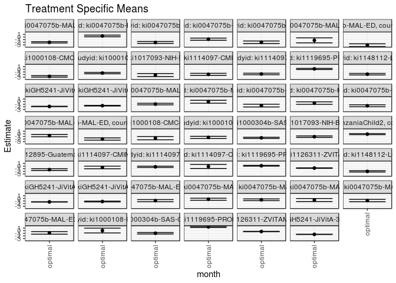

## Results Table

### Parameter: TSM

| agecat | studyid | country | intervention_level | baseline_level | estimate | ci_lower | ci_upper |
| --- | --- | --- | --- | --- | --- | --- | --- |
| Birth | ki0047075b-MAL-ED | BANGLADESH | optimal | observed | -0.8599650 | -1.2719363 | -0.4479936 |
| Birth | ki0047075b-MAL-ED | BRAZIL | optimal | observed | -0.3186200 | -0.7043154 | 0.0670754 |
| Birth | ki0047075b-MAL-ED | INDIA | optimal | observed | -0.5313605 | -0.8668145 | -0.1959065 |
| Birth | ki0047075b-MAL-ED | NEPAL | optimal | observed | -0.6262730 | -1.2071105 | -0.0454355 |
| Birth | ki0047075b-MAL-ED | PERU | optimal | observed | -0.8269554 | -1.2845782 | -0.3693326 |
| Birth | ki0047075b-MAL-ED | SOUTH AFRICA | optimal | observed | -0.8537991 | -1.3503686 | -0.3572296 |
| Birth | ki1000108-IRC | INDIA | optimal | observed | 0.0455405 | -0.8729151 | 0.9639962 |
| Birth | ki1000304b-SAS-CompFeed | INDIA | optimal | observed | -0.9870283 | -1.2667816 | -0.7072750 |
| Birth | ki1119695-PROBIT | BELARUS | optimal | observed | 1.4577708 | 1.2573176 | 1.6582240 |
| Birth | ki1126311-ZVITAMBO | ZIMBABWE | optimal | observed | -0.3236755 | -0.3892115 | -0.2581395 |
| Birth | kiGH5241-JiVitA-3 | BANGLADESH | optimal | observed | -1.4112929 | -1.4715813 | -1.3510045 |
| 6 months | ki0047075b-MAL-ED | BANGLADESH | optimal | observed | -0.9499262 | -1.2490278 | -0.6508246 |
| 6 months | ki0047075b-MAL-ED | BRAZIL | optimal | observed | -0.0666956 | -0.6218941 | 0.4885029 |
| 6 months | ki0047075b-MAL-ED | INDIA | optimal | observed | -1.5287506 | -2.0673482 | -0.9901529 |
| 6 months | ki0047075b-MAL-ED | NEPAL | optimal | observed | -0.5712740 | -1.0514803 | -0.0910677 |
| 6 months | ki0047075b-MAL-ED | PERU | optimal | observed | -1.6071275 | -1.9825637 | -1.2316912 |
| 6 months | ki0047075b-MAL-ED | SOUTH AFRICA | optimal | observed | -0.6885114 | -1.1140713 | -0.2629516 |
| 6 months | ki0047075b-MAL-ED | TANZANIA, UNITED REPUBLIC OF | optimal | observed | -1.9718041 | -2.4035113 | -1.5400969 |
| 6 months | ki1000108-CMC-V-BCS-2002 | INDIA | optimal | observed | -1.6488108 | -2.2749744 | -1.0226472 |
| 6 months | ki1000108-IRC | INDIA | optimal | observed | -1.3555503 | -1.7587533 | -0.9523472 |
| 6 months | ki1000304b-SAS-CompFeed | INDIA | optimal | observed | -1.5182755 | -1.7407625 | -1.2957885 |
| 6 months | ki1017093-NIH-Birth | BANGLADESH | optimal | observed | -1.0908077 | -1.3915791 | -0.7900362 |
| 6 months | ki1066203-TanzaniaChild2 | TANZANIA, UNITED REPUBLIC OF | optimal | observed | -0.1060083 | -0.3171222 | 0.1051056 |
| 6 months | ki1112895-Guatemala BSC | GUATEMALA | optimal | observed | -1.3454567 | -1.6901375 | -1.0007759 |
| 6 months | ki1114097-CMIN | GUINEA-BISSAU | optimal | observed | -0.5149572 | -1.0277683 | -0.0021461 |
| 6 months | ki1114097-CMIN | PERU | optimal | observed | -0.2530911 | -0.5116566 | 0.0054745 |
| 6 months | ki1114097-CONTENT | PERU | optimal | observed | -0.1234790 | -0.8911313 | 0.6441733 |
| 6 months | ki1119695-PROBIT | BELARUS | optimal | observed | 0.1436762 | -0.0117505 | 0.2991029 |
| 6 months | ki1126311-ZVITAMBO | ZIMBABWE | optimal | observed | -0.7507926 | -0.8382220 | -0.6633632 |
| 6 months | ki1148112-LCNI-5 | MALAWI | optimal | observed | -1.9985139 | -2.2496304 | -1.7473974 |
| 6 months | kiGH5241-JiVitA-3 | BANGLADESH | optimal | observed | -1.3394648 | -1.4081408 | -1.2707889 |
| 6 months | kiGH5241-JiVitA-4 | BANGLADESH | optimal | observed | -1.1901321 | -1.3477829 | -1.0324814 |
| 24 months | ki0047075b-MAL-ED | BANGLADESH | optimal | observed | -2.0268762 | -2.2882597 | -1.7654927 |
| 24 months | ki0047075b-MAL-ED | BRAZIL | optimal | observed | 0.4126814 | 0.0944773 | 0.7308854 |
| 24 months | ki0047075b-MAL-ED | INDIA | optimal | observed | -2.0672511 | -2.4327157 | -1.7017865 |
| 24 months | ki0047075b-MAL-ED | NEPAL | optimal | observed | -0.8244567 | -1.2439556 | -0.4049579 |
| 24 months | ki0047075b-MAL-ED | PERU | optimal | observed | -1.9952563 | -2.4775204 | -1.5129922 |
| 24 months | ki0047075b-MAL-ED | SOUTH AFRICA | optimal | observed | -1.2720268 | -2.2270264 | -0.3170272 |
| 24 months | ki0047075b-MAL-ED | TANZANIA, UNITED REPUBLIC OF | optimal | observed | -3.1025457 | -3.6201179 | -2.5849736 |
| 24 months | ki1000108-CMC-V-BCS-2002 | INDIA | optimal | observed | -2.7077286 | -2.9862095 | -2.4292476 |
| 24 months | ki1000108-IRC | INDIA | optimal | observed | -1.4272821 | -1.6947687 | -1.1597954 |
| 24 months | ki1017093-NIH-Birth | BANGLADESH | optimal | observed | -2.1883148 | -2.7680154 | -1.6086143 |
| 24 months | ki1114097-CMIN | GUINEA-BISSAU | optimal | observed | -1.9317868 | -2.3236097 | -1.5399640 |
| 24 months | ki1114097-CMIN | PERU | optimal | observed | -1.7950084 | -2.0805676 | -1.5094492 |
| 24 months | ki1119695-PROBIT | BELARUS | optimal | observed | 0.1627707 | -0.0519412 | 0.3774826 |
| 24 months | ki1148112-LCNI-5 | MALAWI | optimal | observed | -1.8647101 | -2.1683732 | -1.5610469 |
| 24 months | kiGH5241-JiVitA-3 | BANGLADESH | optimal | observed | -1.8662802 | -1.9573048 | -1.7752556 |
| 24 months | kiGH5241-JiVitA-4 | BANGLADESH | optimal | observed | -1.5741234 | -1.6971552 | -1.4510915 |

### Parameter: E(Y)

| agecat | studyid | country | intervention_level | baseline_level | estimate | ci_lower | ci_upper |
| --- | --- | --- | --- | --- | --- | --- | --- |
| Birth | ki0047075b-MAL-ED | BANGLADESH | observed | observed | -1.0843969 | -1.2100768 | -0.9587169 |
| Birth | ki0047075b-MAL-ED | BRAZIL | observed | observed | -0.7609424 | -0.9178311 | -0.6040538 |
| Birth | ki0047075b-MAL-ED | INDIA | observed | observed | -1.0106311 | -1.1499962 | -0.8712660 |
| Birth | ki0047075b-MAL-ED | NEPAL | observed | observed | -0.7089017 | -0.8656064 | -0.5521971 |
| Birth | ki0047075b-MAL-ED | PERU | observed | observed | -0.9322300 | -1.0461262 | -0.8183337 |
| Birth | ki0047075b-MAL-ED | SOUTH AFRICA | observed | observed | -0.7266031 | -0.8549719 | -0.5982342 |
| Birth | ki1000108-IRC | INDIA | observed | observed | -0.3080412 | -0.4687931 | -0.1472894 |
| Birth | ki1000304b-SAS-CompFeed | INDIA | observed | observed | -1.3946524 | -1.5833612 | -1.2059436 |
| Birth | ki1119695-PROBIT | BELARUS | observed | observed | 1.3254775 | 1.1669293 | 1.4840258 |
| Birth | ki1126311-ZVITAMBO | ZIMBABWE | observed | observed | -0.5011749 | -0.5217748 | -0.4805751 |
| Birth | kiGH5241-JiVitA-3 | BANGLADESH | observed | observed | -1.5747407 | -1.5944667 | -1.5550147 |
| 6 months | ki0047075b-MAL-ED | BANGLADESH | observed | observed | -1.2056777 | -1.3231497 | -1.0882058 |
| 6 months | ki0047075b-MAL-ED | BRAZIL | observed | observed | 0.0510207 | -0.0930194 | 0.1950608 |
| 6 months | ki0047075b-MAL-ED | INDIA | observed | observed | -1.2203672 | -1.3387619 | -1.1019726 |
| 6 months | ki0047075b-MAL-ED | NEPAL | observed | observed | -0.5610593 | -0.6737915 | -0.4483272 |
| 6 months | ki0047075b-MAL-ED | PERU | observed | observed | -1.3268010 | -1.4351217 | -1.2184802 |
| 6 months | ki0047075b-MAL-ED | SOUTH AFRICA | observed | observed | -1.0633760 | -1.1911088 | -0.9356432 |
| 6 months | ki0047075b-MAL-ED | TANZANIA, UNITED REPUBLIC OF | observed | observed | -1.3601215 | -1.4821830 | -1.2380600 |
| 6 months | ki1000108-CMC-V-BCS-2002 | INDIA | observed | observed | -1.4234508 | -1.5645974 | -1.2823042 |
| 6 months | ki1000108-IRC | INDIA | observed | observed | -1.2344062 | -1.3658524 | -1.1029600 |
| 6 months | ki1000304b-SAS-CompFeed | INDIA | observed | observed | -1.4018563 | -1.4810585 | -1.3226541 |
| 6 months | ki1017093-NIH-Birth | BANGLADESH | observed | observed | -1.4073821 | -1.4960598 | -1.3187043 |
| 6 months | ki1066203-TanzaniaChild2 | TANZANIA, UNITED REPUBLIC OF | observed | observed | -0.5434389 | -0.5924056 | -0.4944722 |
| 6 months | ki1112895-Guatemala BSC | GUATEMALA | observed | observed | -1.5619008 | -1.6727702 | -1.4510313 |
| 6 months | ki1114097-CMIN | GUINEA-BISSAU | observed | observed | -0.6075943 | -0.6832781 | -0.5319106 |
| 6 months | ki1114097-CMIN | PERU | observed | observed | -0.5132548 | -0.5926717 | -0.4338380 |
| 6 months | ki1114097-CONTENT | PERU | observed | observed | -0.3139217 | -0.4868486 | -0.1409948 |
| 6 months | ki1119695-PROBIT | BELARUS | observed | observed | 0.1069986 | 0.0122286 | 0.2017686 |
| 6 months | ki1126311-ZVITAMBO | ZIMBABWE | observed | observed | -0.8905937 | -0.9165852 | -0.8646022 |
| 6 months | ki1148112-LCNI-5 | MALAWI | observed | observed | -1.6601907 | -1.7297701 | -1.5906113 |
| 6 months | kiGH5241-JiVitA-3 | BANGLADESH | observed | observed | -1.3130932 | -1.3362359 | -1.2899505 |
| 6 months | kiGH5241-JiVitA-4 | BANGLADESH | observed | observed | -1.3447940 | -1.3820261 | -1.3075620 |
| 24 months | ki0047075b-MAL-ED | BANGLADESH | observed | observed | -1.9431132 | -2.0691678 | -1.8170586 |
| 24 months | ki0047075b-MAL-ED | BRAZIL | observed | observed | 0.0418343 | -0.1253834 | 0.2090521 |
| 24 months | ki0047075b-MAL-ED | INDIA | observed | observed | -1.8458150 | -1.9718703 | -1.7197596 |
| 24 months | ki0047075b-MAL-ED | NEPAL | observed | observed | -1.2752193 | -1.3954783 | -1.1549603 |
| 24 months | ki0047075b-MAL-ED | PERU | observed | observed | -1.7500995 | -1.8705474 | -1.6296516 |
| 24 months | ki0047075b-MAL-ED | SOUTH AFRICA | observed | observed | -1.6228361 | -1.7581177 | -1.4875546 |
| 24 months | ki0047075b-MAL-ED | TANZANIA, UNITED REPUBLIC OF | observed | observed | -2.6058879 | -2.7403043 | -2.4714714 |
| 24 months | ki1000108-CMC-V-BCS-2002 | INDIA | observed | observed | -2.5593683 | -2.6601027 | -2.4586339 |
| 24 months | ki1000108-IRC | INDIA | observed | observed | -1.7824776 | -1.8765600 | -1.6883952 |
| 24 months | ki1017093-NIH-Birth | BANGLADESH | observed | observed | -2.1807945 | -2.2835902 | -2.0779987 |
| 24 months | ki1114097-CMIN | GUINEA-BISSAU | observed | observed | -1.5745644 | -1.6739586 | -1.4751703 |
| 24 months | ki1114097-CMIN | PERU | observed | observed | -1.5807226 | -1.6772768 | -1.4841684 |
| 24 months | ki1119695-PROBIT | BELARUS | observed | observed | -0.1314048 | -0.4282725 | 0.1654630 |
| 24 months | ki1148112-LCNI-5 | MALAWI | observed | observed | -1.8754404 | -1.9564117 | -1.7944692 |
| 24 months | kiGH5241-JiVitA-3 | BANGLADESH | observed | observed | -2.0126460 | -2.0403823 | -1.9849097 |
| 24 months | kiGH5241-JiVitA-4 | BANGLADESH | observed | observed | -1.7582681 | -1.7937283 | -1.7228079 |

### Parameter: PAR

| agecat | studyid | country | intervention_level | baseline_level | estimate | ci_lower | ci_upper |
| --- | --- | --- | --- | --- | --- | --- | --- |
| Birth | ki0047075b-MAL-ED | BANGLADESH | optimal | observed | -0.2244319 | -0.6194731 | 0.1706093 |
| Birth | ki0047075b-MAL-ED | BRAZIL | optimal | observed | -0.4423224 | -0.8278153 | -0.0568295 |
| Birth | ki0047075b-MAL-ED | INDIA | optimal | observed | -0.4792706 | -0.8200626 | -0.1384786 |
| Birth | ki0047075b-MAL-ED | NEPAL | optimal | observed | -0.0826287 | -0.6318803 | 0.4666229 |
| Birth | ki0047075b-MAL-ED | PERU | optimal | observed | -0.1052746 | -0.5459667 | 0.3354175 |
| Birth | ki0047075b-MAL-ED | SOUTH AFRICA | optimal | observed | 0.1271960 | -0.3564181 | 0.6108101 |
| Birth | ki1000108-IRC | INDIA | optimal | observed | -0.3535818 | -1.2308485 | 0.5236850 |
| Birth | ki1000304b-SAS-CompFeed | INDIA | optimal | observed | -0.4076241 | -0.6736644 | -0.1415839 |
| Birth | ki1119695-PROBIT | BELARUS | optimal | observed | -0.1322933 | -0.2342134 | -0.0303732 |
| Birth | ki1126311-ZVITAMBO | ZIMBABWE | optimal | observed | -0.1774994 | -0.2404069 | -0.1145919 |
| Birth | kiGH5241-JiVitA-3 | BANGLADESH | optimal | observed | -0.1634479 | -0.2211369 | -0.1057589 |
| 6 months | ki0047075b-MAL-ED | BANGLADESH | optimal | observed | -0.2557516 | -0.5515917 | 0.0400885 |
| 6 months | ki0047075b-MAL-ED | BRAZIL | optimal | observed | 0.1177164 | -0.4259704 | 0.6614032 |
| 6 months | ki0047075b-MAL-ED | INDIA | optimal | observed | 0.3083833 | -0.2011539 | 0.8179205 |
| 6 months | ki0047075b-MAL-ED | NEPAL | optimal | observed | 0.0102147 | -0.4486766 | 0.4691060 |
| 6 months | ki0047075b-MAL-ED | PERU | optimal | observed | 0.2803265 | -0.0879397 | 0.6485926 |
| 6 months | ki0047075b-MAL-ED | SOUTH AFRICA | optimal | observed | -0.3748645 | -0.8021883 | 0.0524593 |
| 6 months | ki0047075b-MAL-ED | TANZANIA, UNITED REPUBLIC OF | optimal | observed | 0.6116826 | 0.1982253 | 1.0251399 |
| 6 months | ki1000108-CMC-V-BCS-2002 | INDIA | optimal | observed | 0.2253600 | -0.3731484 | 0.8238684 |
| 6 months | ki1000108-IRC | INDIA | optimal | observed | 0.1211440 | -0.2680175 | 0.5103056 |
| 6 months | ki1000304b-SAS-CompFeed | INDIA | optimal | observed | 0.1164192 | -0.1236668 | 0.3565052 |
| 6 months | ki1017093-NIH-Birth | BANGLADESH | optimal | observed | -0.3165744 | -0.6031196 | -0.0300292 |
| 6 months | ki1066203-TanzaniaChild2 | TANZANIA, UNITED REPUBLIC OF | optimal | observed | -0.4374306 | -0.6384662 | -0.2363950 |
| 6 months | ki1112895-Guatemala BSC | GUATEMALA | optimal | observed | -0.2164441 | -0.5469495 | 0.1140613 |
| 6 months | ki1114097-CMIN | GUINEA-BISSAU | optimal | observed | -0.0926371 | -0.5900751 | 0.4048008 |
| 6 months | ki1114097-CMIN | PERU | optimal | observed | -0.2601638 | -0.5047931 | -0.0155344 |
| 6 months | ki1114097-CONTENT | PERU | optimal | observed | -0.1904427 | -0.9504622 | 0.5695768 |
| 6 months | ki1119695-PROBIT | BELARUS | optimal | observed | -0.0366776 | -0.1643248 | 0.0909697 |
| 6 months | ki1126311-ZVITAMBO | ZIMBABWE | optimal | observed | -0.1398011 | -0.2223221 | -0.0572801 |
| 6 months | ki1148112-LCNI-5 | MALAWI | optimal | observed | 0.3383232 | 0.0980586 | 0.5785878 |
| 6 months | kiGH5241-JiVitA-3 | BANGLADESH | optimal | observed | 0.0263716 | -0.0380625 | 0.0908058 |
| 6 months | kiGH5241-JiVitA-4 | BANGLADESH | optimal | observed | -0.1546619 | -0.3102661 | 0.0009423 |
| 24 months | ki0047075b-MAL-ED | BANGLADESH | optimal | observed | 0.0837630 | -0.1830184 | 0.3505444 |
| 24 months | ki0047075b-MAL-ED | BRAZIL | optimal | observed | -0.3708471 | -0.7073166 | -0.0343775 |
| 24 months | ki0047075b-MAL-ED | INDIA | optimal | observed | 0.2214361 | -0.1389777 | 0.5818500 |
| 24 months | ki0047075b-MAL-ED | NEPAL | optimal | observed | -0.4507626 | -0.8617400 | -0.0397851 |
| 24 months | ki0047075b-MAL-ED | PERU | optimal | observed | 0.2451568 | -0.2193313 | 0.7096449 |
| 24 months | ki0047075b-MAL-ED | SOUTH AFRICA | optimal | observed | -0.3508093 | -1.2852851 | 0.5836665 |
| 24 months | ki0047075b-MAL-ED | TANZANIA, UNITED REPUBLIC OF | optimal | observed | 0.4966579 | 0.0018429 | 0.9914728 |
| 24 months | ki1000108-CMC-V-BCS-2002 | INDIA | optimal | observed | 0.1483603 | -0.1219493 | 0.4186699 |
| 24 months | ki1000108-IRC | INDIA | optimal | observed | -0.3551955 | -0.6151678 | -0.0952232 |
| 24 months | ki1017093-NIH-Birth | BANGLADESH | optimal | observed | 0.0075203 | -0.5558571 | 0.5708978 |
| 24 months | ki1114097-CMIN | GUINEA-BISSAU | optimal | observed | 0.3572224 | -0.0247691 | 0.7392139 |
| 24 months | ki1114097-CMIN | PERU | optimal | observed | 0.2142858 | -0.0761170 | 0.5046885 |
| 24 months | ki1119695-PROBIT | BELARUS | optimal | observed | -0.2941755 | -0.5874810 | -0.0008699 |
| 24 months | ki1148112-LCNI-5 | MALAWI | optimal | observed | -0.0107304 | -0.3128926 | 0.2914319 |
| 24 months | kiGH5241-JiVitA-3 | BANGLADESH | optimal | observed | -0.1463658 | -0.2326220 | -0.0601096 |
| 24 months | kiGH5241-JiVitA-4 | BANGLADESH | optimal | observed | -0.1841447 | -0.3065042 | -0.0617853 |